# Linear models example: Occupational Prestige data

Michael Friendly

15 Nov 2021

## Load packages & Prestige data

The `car` and `effects` packages are the main workhorses here.

```r
library("car")
library("effects")  # effect plots
library("arm")      # coefplots
data(Prestige, package="carData")
```

## Reorder levels of `type` factor

Here it is useful to recognize that “bc” < “wc” < “prof”. Do so by making `Prestige$type` an ordered factor. Note that the occupation names are the `row.names` in the data.frame, not a separate variable.

```r
Prestige$type <- ordered(Prestige$type, levels=c("bc", "wc", "prof")) # reorder levels
some(Prestige, 6)
```

```
##                     education income women prestige census type
## librarians              14.15   6112 77.10     58.1   2351 prof
## university.teachers     15.97  12480 19.59     84.6   2711 prof
## veterinarians           15.94  14558  4.32     66.7   3115 prof
## travel.clerks           11.43   6259 39.17     35.7   4193   wc
## bartenders               8.50   3930 15.51     20.2   6123   bc
## taxi.drivers             7.93   4224  3.59     25.1   9173   bc
```

## scatterplotMatrix

Let’s get a visual overview of the data in a scatterplot matrix. I use options to specify a linear regression line (`regLine=`), a loess smoothed curve (`smooth=`) and a 68% (~ $\bar{y} \pm 1 sd$) data ellipse (`ellipse=`) in each panel.

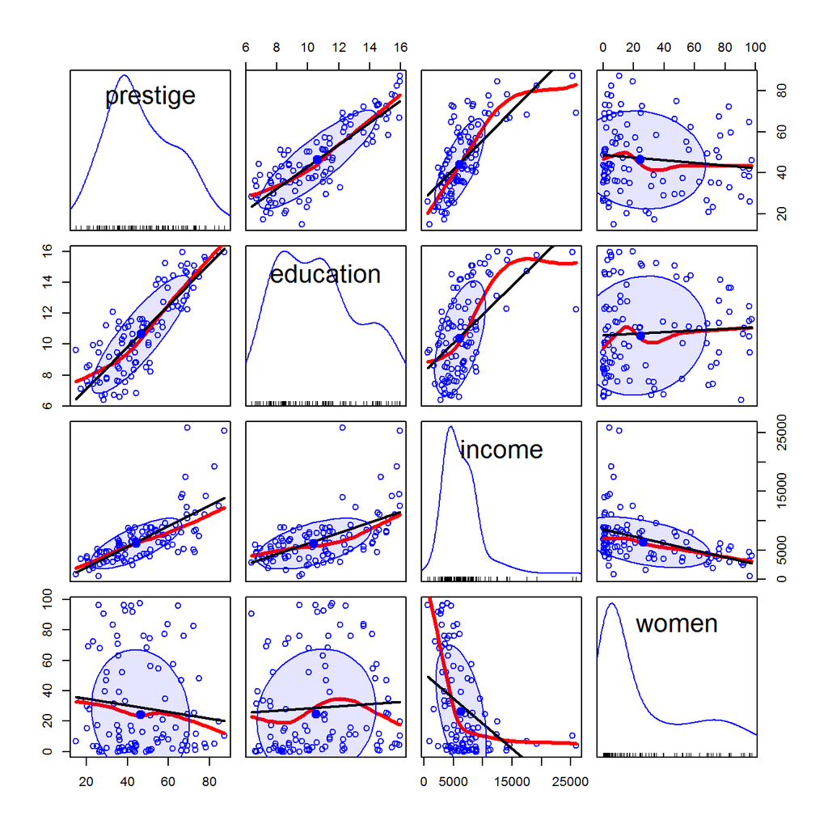

```r
scatterplotMatrix(~ prestige + education + income + women ,
                  data=Prestige,
                  regLine = list(method=lm, lty=1, lwd=2, col="black"),
                  smooth=list(smoother=loessLine, spread=FALSE,
                              lty.smooth=1, lwd.smooth=3, col.smooth="red"),
                  ellipse=list(levels=0.68, fill.alpha=0.1))
```

## Fancy scatterplots

`car::scatterplot` has many options to add informative annotations, label unusual points, etc. This plot shows clearly that income is positively skewed and the relation with `prestige` is non-linear. The `id =` argument allows to identify unusual observations with their labels

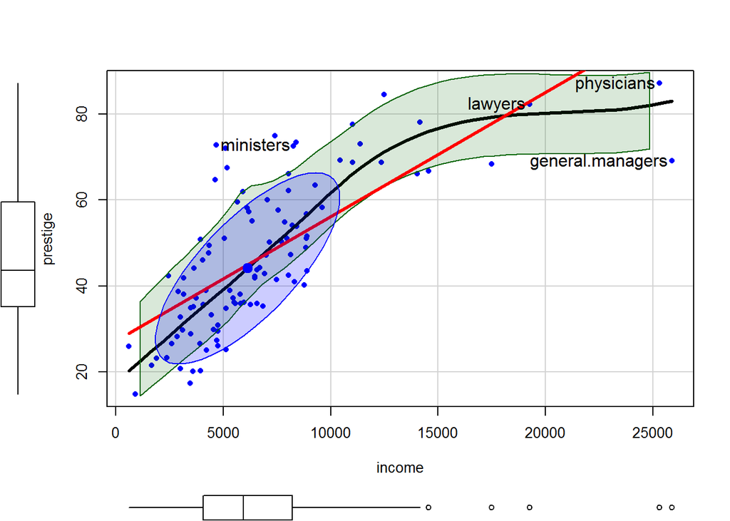

```
## general.managers          lawyers        ministers       physicians
##                2               17               20               24
```

```r
scatterplot(prestige ~ income, data=Prestige,
            pch = 16,
            regLine = list(col = "red", lwd=3),
            smooth = list(smoother=loessLine,
                          lty.smooth = 1, col.smooth = "black", lwd.smooth=3,
                          col.var = "darkgreen"),
            ellipse = list(levels = 0.68),
            id = list(n=4, col="black", cex=1.2))
```

### What would log(income) look like?

Rather than actually transforming `income`, the argument `log = "x"` says to plot `income` on a log scale

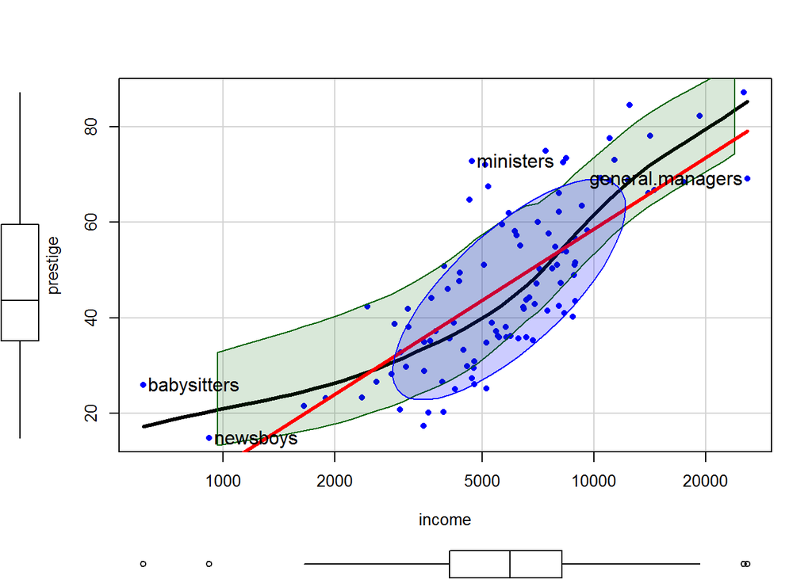

```
## general.managers        ministers         newsboys      babysitters
##                2               20               53               63
```

```r
scatterplot(prestige ~ income, data=Prestige,
            log = "x",
            pch = 16,
            regLine = list(col = "red", lwd=3),
            smooth = list(smoother=loessLine,
                          lty.smooth = 1, col.smooth = "black", lwd.smooth=3,
                          col.var = "darkgreen"),
            ellipse = list(levels = 0.68),
            id = list(n=4, col="black", cex=1.2))
```

### Stratify by type

The formula notation `~ income | type` says to do plot annotations conditional on occupation type. Oh, now that has a very different interpretation!

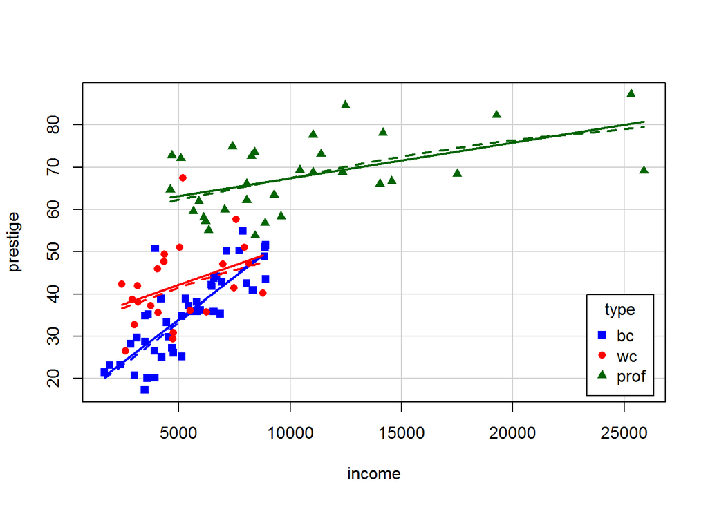

```r
scatterplot(prestige ~ income | type, data=Prestige,
            col = c("blue", "red", "darkgreen"),
            pch = 15:17,
            legend = list(coords="bottomright"),
            smooth=list(smoother=loessLine,
                        var=FALSE, span=1, lwd=4))
```

## Fit the basic all-main-effects model

```r
data(Prestige)
mod0 <- lm(prestige ~ education + income + women + type,
           data=Prestige)
summary(mod0)
```

```
##
## Call:
## lm(formula = prestige ~ education + income + women + type, data = Prestige)
##
## Residuals:
##     Min      1Q  Median      3Q     Max
## -14.748  -4.482   0.312   5.248  18.498
##
## Coefficients:
##              Estimate Std. Error t value Pr(>|t|)
## (Intercept) -0.813903   5.331156   -0.15  0.87899
## education    3.662356   0.645830    5.67  1.6e-07 ***
## income       0.001043   0.000262    3.98  0.00014 ***
## women        0.006443   0.030378    0.21  0.83249
## typeprof     5.905197   3.937700    1.50  0.13713
## typewc      -2.917072   2.665396   -1.09  0.27663
## ---
## Signif. codes:  0 '***' 0.001 '**' 0.01 '*' 0.05 '.' 0.1 ' ' 1
##
## Residual standard error: 7.13 on 92 degrees of freedom
##   (4 observations deleted due to missingness)
## Multiple R-squared:  0.835,  Adjusted R-squared:  0.826
## F-statistic: 93.1 on 5 and 92 DF,  p-value: <2e-16
```

## Add more complex terms

Here we model income as `` log(income)`` and allow an interaction with occupation ``type`.

```r
mod1 <- lm(prestige ~ education + women +
                     log(income)*type, data=Prestige)
summary(mod1)
```

```
##
## Call:
## lm(formula = prestige ~ education + women + log(income) * type,
##     data = Prestige)
##
## Residuals:
##     Min      1Q  Median      3Q     Max
## -13.814  -4.685   0.656   3.966  16.569
##
## Coefficients:
##                       Estimate Std. Error t value Pr(>|t|)
## (Intercept)          -152.2059    23.2499   -6.55  3.5e-09 ***
## education               2.9282     0.5883    4.98  3.1e-06 ***
## women                   0.0883     0.0323    2.73   0.0076 **
## log(income)            18.9819     2.8285    6.71  1.7e-09 ***
## typeprof               85.2642    30.4582    2.80   0.0063 **
## typewc                 29.4133    36.5075    0.81   0.4226
## log(income):typeprof   -9.0124     3.4102   -2.64   0.0097 **
## log(income):typewc     -3.8334     4.2603   -0.90   0.3706
## ---
## Signif. codes:  0 '***' 0.001 '**' 0.01 '*' 0.05 '.' 0.1 ' ' 1
##
## Residual standard error: 6.27 on 90 degrees of freedom
##   (4 observations deleted due to missingness)
## Multiple R-squared:  0.875,  Adjusted R-squared:  0.865
## F-statistic: 90.1 on 7 and 90 DF,  p-value: <2e-16
```

## Plot coefficients

Plots of coefficients with CI often more informative that tables of coefficients. These intervals are shown for $\pm 1, \pm 2$ standard errors.

However, this plots the *raw coefficients*, which are on different scales, so the small coefficients for `income` do not appear to be significant. It would be better if there was an option to plot standardized ($\beta$) coefficients.

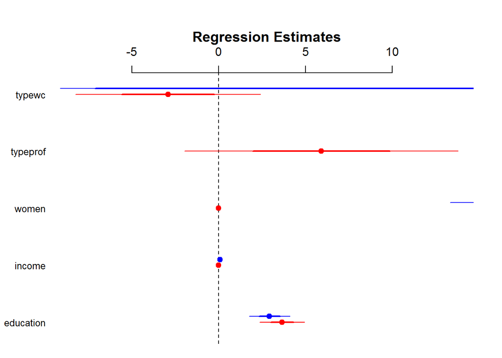

```r
arm::coefplot(mod0, col.pts="red", cex.pts=1.5)
arm::coefplot(mod1, add=TRUE, col.pts="blue", cex.pts=1.5)
```

## Compare model fits

This `anova` call tests whether `mod1` is a significant improvement over the baseline `mod0`

```r
anova(mod0, mod1)
```

```
## Analysis of Variance Table
##
## Model 1: prestige ~ education + income + women + type
## Model 2: prestige ~ education + women + log(income) * type
##   Res.Df  RSS Df Sum of Sq    F  Pr(>F)
## 1     92 4679
## 2     90 3541  2      1138 14.5 3.6e-06 ***
## ---
## Signif. codes:  0 '***' 0.001 '**' 0.01 '*' 0.05 '.' 0.1 ' ' 1
```

## Effect plots

Effect of `education` averaged over others

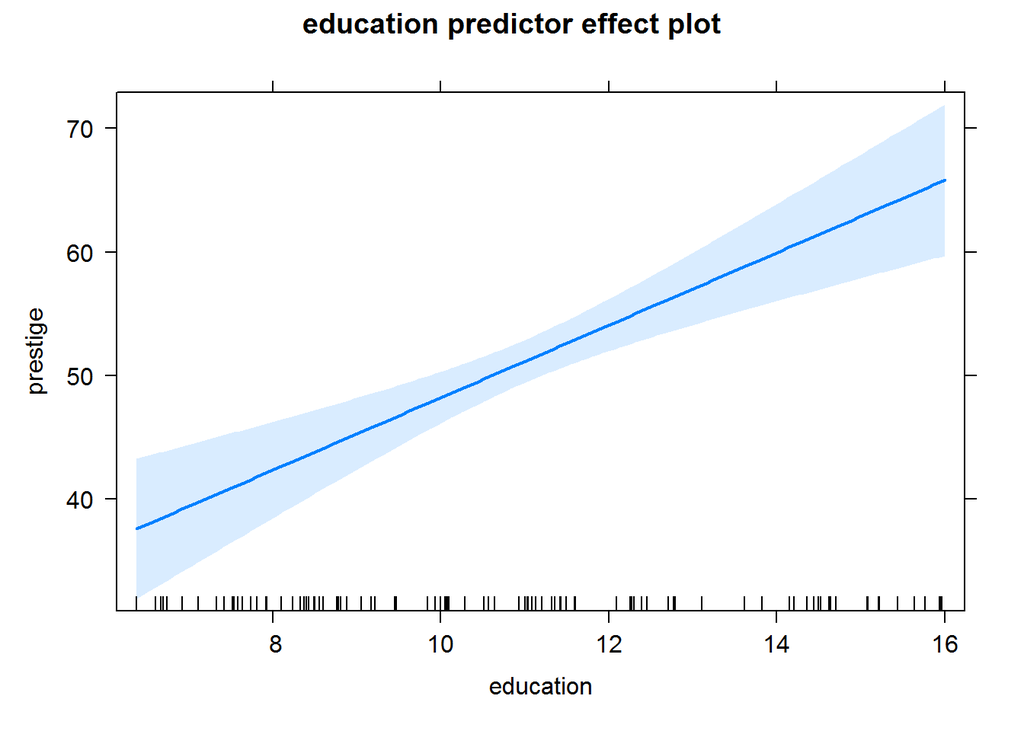

```r
mod1.e1 <- predictorEffect("education", mod1)
plot(mod1.e1)
```

Effect of `education`, but showing partial residuals. In some cases, this will help spot influential cases in the partial relation of a predictor to the response.

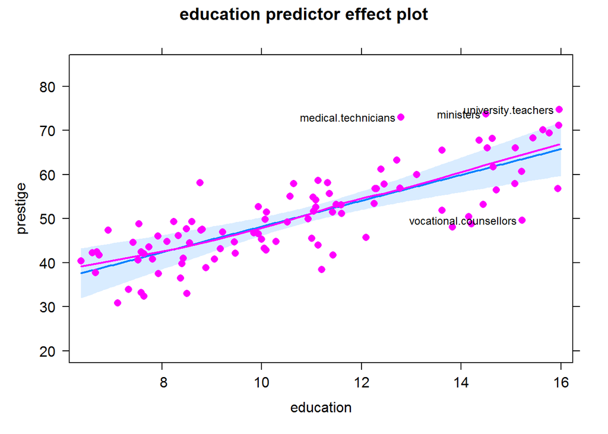

```r
mod1.e1a <- predictorEffect("education", mod1, residuals=TRUE)
plot(mod1.e1a,
     residuals.pch=16, id=list(n=4, col="black"))
```

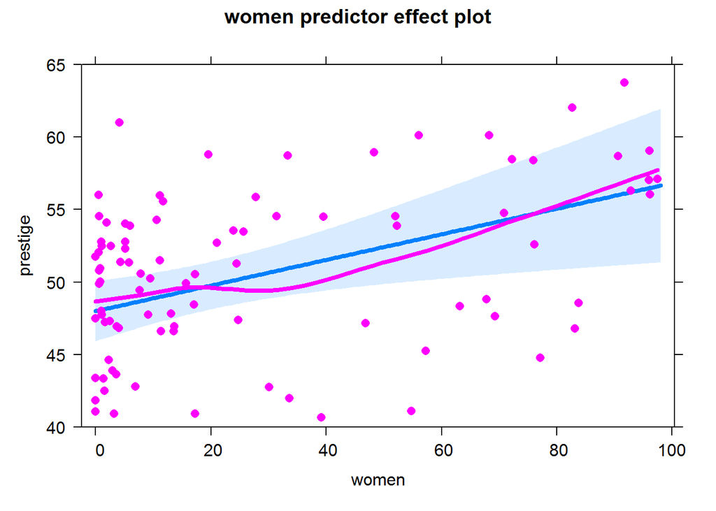

```r
mod1.e2 <- predictorEffect("women", mod1, residuals=TRUE)
plot(mod1.e2, ylim=c(40, 65), lwd=4,
     residuals.pch=16)
```

Effect of `income` (by `type`) averaged over others

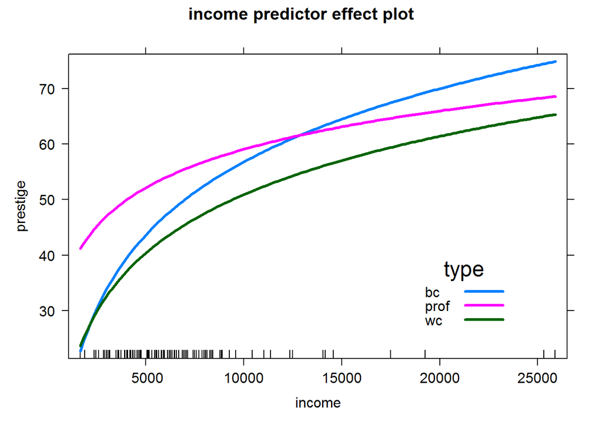

```r
plot(predictorEffect("income", mod1),
     lines=list(multiline=TRUE, lwd=3),
     key.args = list(x=.7, y=.35),
    )
```

## Diagnostic plots

In base graphics, `plot()` for an `lm` object gives the “regression quartet” of diagnostic plots.

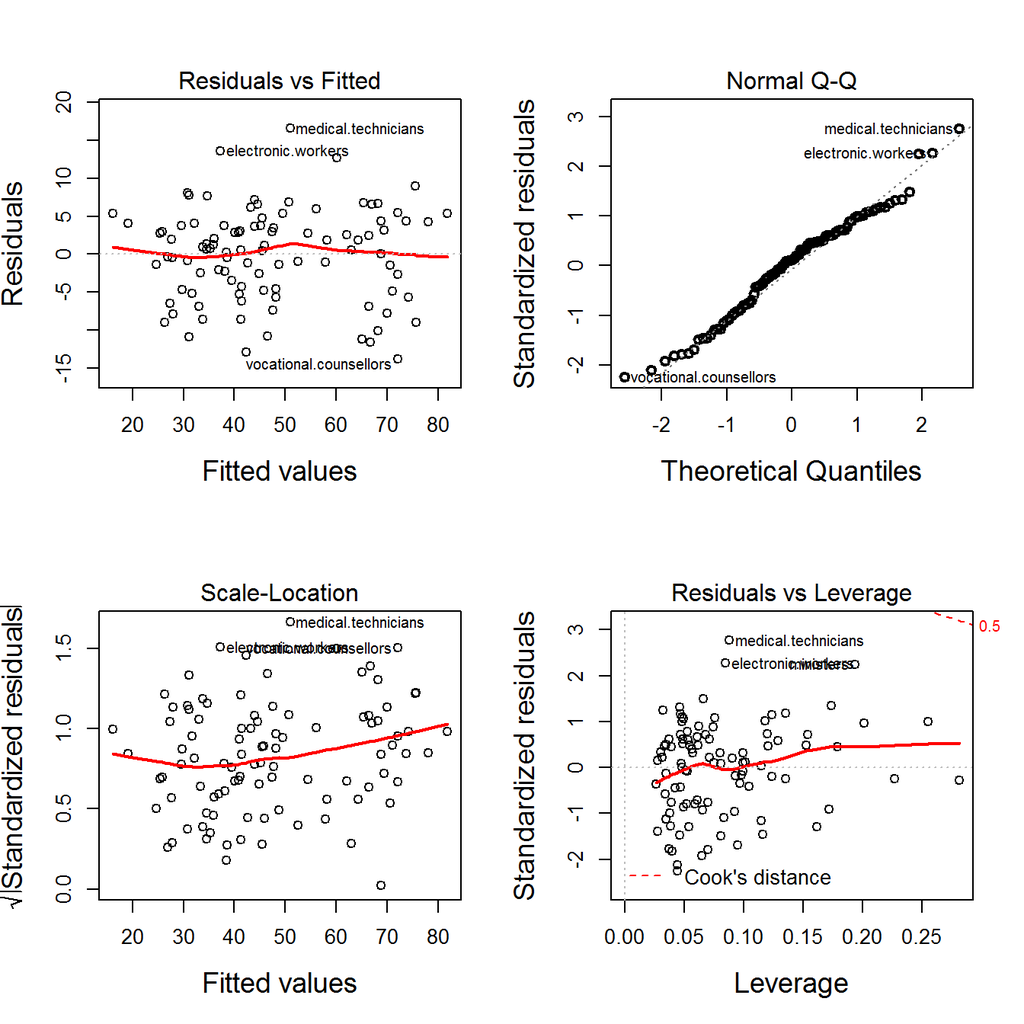

```r
op <- par(mfrow=c(2,2))
plot(mod1, lwd=2, cex.lab=1.4)
```

## better QQ plots from `car::qqPlot`

Overall plot of residuals for `mod1`

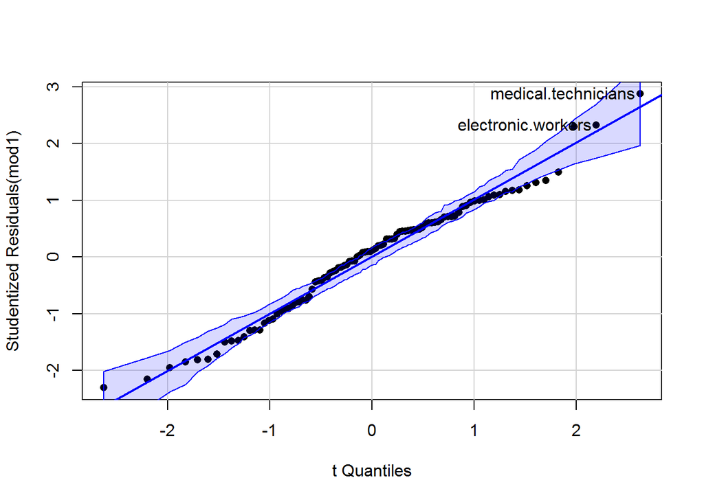

```
## medical.technicians  electronic.workers
##                  31                  82
```

```r
qqPlot(mod1, pch=16)
```

QQ plots for individual variables and/or subsets

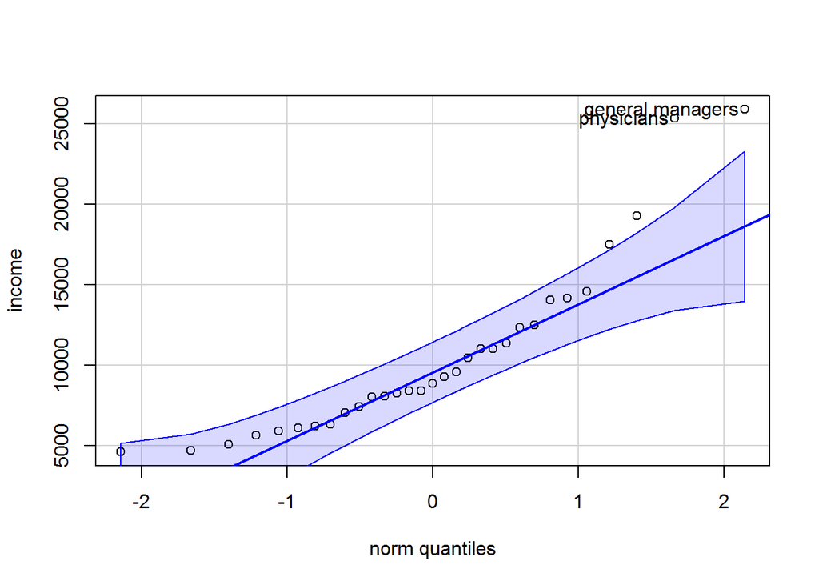

```
## general.managers       physicians
##                2               24
```

```r
qqPlot(~ income, data=Prestige, subset = type == "prof")
```

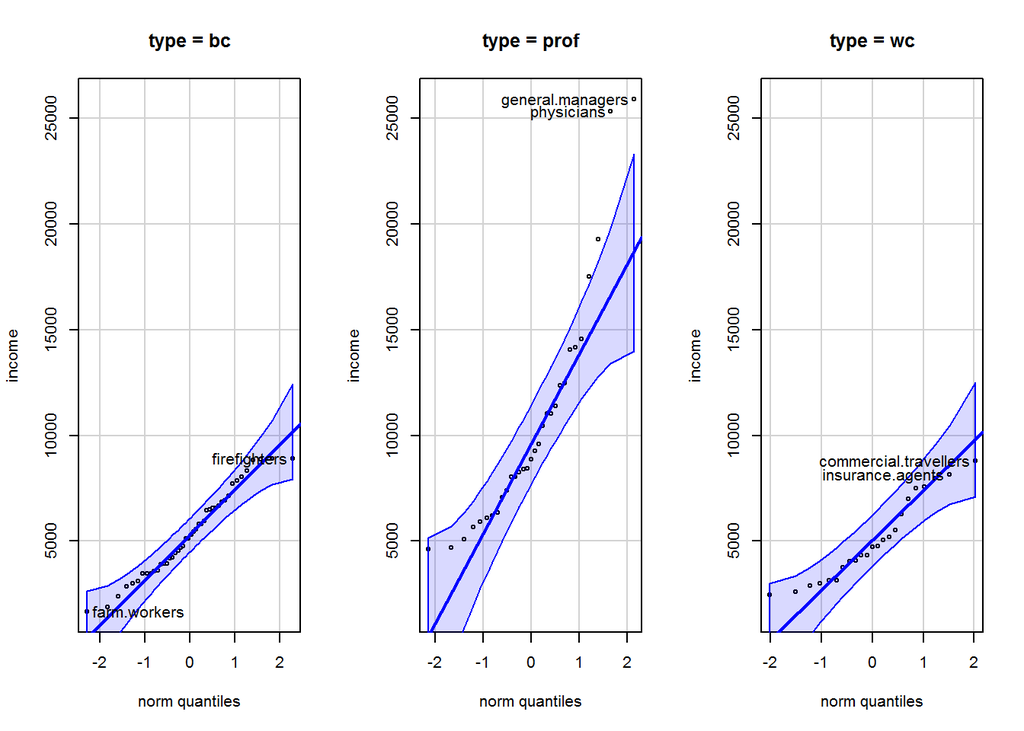

```r
qqPlot(income ~ type, data=Prestige, layout=c(1, 3))
```

## influence plot

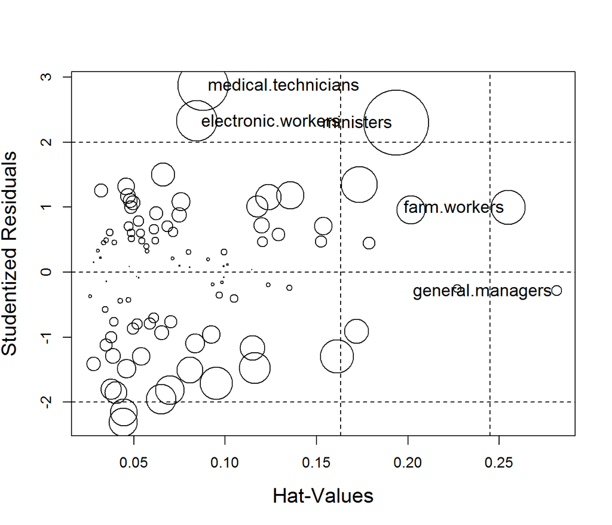

```
##                     StudRes     Hat    CookD
## general.managers    -0.2834 0.28128 0.003969
## ministers            2.2992 0.19369 0.151516
## medical.technicians  2.8757 0.08799 0.092273
## farm.workers         0.9930 0.25501 0.042201
## electronic.workers   2.3233 0.08454 0.059407
```

```r
car::influencePlot(mod1, id=list(n=2, cex=1.2), cex.lab=1.4)
```